# 02 — Integration and hydraulic characterisation

Nutrient grab samples, conservative tracer, and event-level hydraulics

Kauan Fonseca

2026-08-26

```r
# mg/L NaCl per uS/cm of background-corrected SpC; laboratory calibration.
NACL_SLOPE <- 0.461159
```

# Scope

Takes the instrument-clean logger series from `01_hobo_qaqc.Rmd` and the revised nutrient grab samples, and builds the analysis-ready tables that feed the inverse transient-storage and nutrient-uptake modelling.

Covers: timestamp reconstruction of the grab samples, harmonisation to long format, a time-varying baseline for NaCl, pairing of each grab to the interpolated logger series, probe-vs-logger reconciliation, event-level hydraulics, and the CaCO₃ co-precipitation correction for SRP.

Hysteresis and the final BTC review live in `03_btc_review.Rmd`.

**Outputs:** `data_derived/btc_nutrients.csv`, `data_derived/btc_conservative.csv`, `data_derived/events.csv`, `data_derived/geochem_check.csv`.

```r
btc_conservative <- read_rds(here("data_derived", "btc_conservative.rds"))
events_hobo      <- read_rds(here("data_derived", "events_hobo.rds"))

# RA 2023-09-06 N slug used 6240 g NaCl, not the 5957 g inherited from the
# combined field-sheet row.
events_hobo <- events_hobo %>%
  mutate(nacl_mass_g = if_else(event_id == "RA_20230906_N", 6240, nacl_mass_g))

btc_conservative %>% distinct(event_id, stream, date, station, slug_label)
```

```
## # A tibble: 13 × 5
##    event_id               stream date       station    slug_label
##    <chr>                  <chr>  <date>     <chr>      <chr>
##  1 CB_20230907_single     CB     2023-09-07 <NA>       <NA>
##  2 CB_20231008_single     CB     2023-10-08 <NA>       <NA>
##  3 CC_20231006_single     CC     2023-10-06 <NA>       <NA>
##  4 CD_20231009_single     CD     2023-10-09 <NA>       <NA>
##  5 RA_20230906_N          RA     2023-09-06 <NA>       N
##  6 RA_20230906_P          RA     2023-09-06 <NA>       P
##  7 RA_20231005_downstream RA     2023-10-05 downstream <NA>
##  8 RA_20231005_upstream   RA     2023-10-05 upstream   <NA>
##  9 RC_20231007_single     RC     2023-10-07 <NA>       <NA>
## 10 RS_20231011_single     RS     2023-10-11 <NA>       <NA>
## 11 SA_20231010_single     SA     2023-10-10 <NA>       <NA>
## 12 SR_20231009_downstream SR     2023-10-09 downstream <NA>
## 13 SR_20231009_upstream   SR     2023-10-09 upstream   <NA>
```

```r
btc_conservative <- btc_conservative %>%
  group_by(event_id) %>%
  mutate(
    baseline_ref = {
      pre <- spc_uscm[time_since_release_s < 0 &
                      spc_uscm > 0.5 * median(spc_uscm, na.rm = TRUE)]
      if (length(pre) >= 3) median(pre, na.rm = TRUE)
      else median(spc_uscm, na.rm = TRUE)
    },
    out_of_water = !is.na(baseline_ref) & spc_uscm < 0.5 * baseline_ref
  ) %>%
  ungroup()

btc_conservative %>%
  filter(out_of_water) %>%
  group_by(event_id) %>%
  summarise(n_flagged = n(), spc_min = min(spc_uscm),
            all_pre = all(time_since_release_s < 0), .groups = "drop")
```

```
## # A tibble: 1 × 4
##   event_id           n_flagged spc_min all_pre
##   <chr>                  <int>   <dbl> <lgl>
## 1 CB_20231008_single         1    118. TRUE
```

```r
btc_conservative <- btc_conservative %>%
  filter(!out_of_water) %>%
  select(-baseline_ref, -out_of_water)

btc_conservative %>% distinct(event_id) %>% nrow()   # esperado: 13 (11 + SR_20231009_downstream + SR_20231009_upstream)
```

```
## [1] 13
```

> **QAQC note.** Events whose window opens after the release have no pre-release stretch, so the baseline reference falls back to the event median. Without that fallback the flag is `NA` and the whole event is dropped by the filter. The row count is the guard.

# 1. Import nutrient grab samples

```r
read_nutrient <- function(path) {
  read_csv(path, show_col_types = FALSE) %>%
    mutate(
      date = ymd(as.character(date)),
      datetime_field = with_tz(
        as.POSIXct(paste(date, time_along_btc), tz = "America/Cuiaba"),
        "America/Sao_Paulo"),
      release_datetime_field = with_tz(
        as.POSIXct(paste(date, release_time), tz = "America/Cuiaba"),
        "America/Sao_Paulo")
    )
}

n_raw <- read_nutrient(here("data", "nutrients", "nutrient_addition_nitrogen_data.csv"))
p_raw <- read_nutrient(here("data", "nutrients", "nutrient_addition_phosphate_data.csv"))

dim(n_raw); dim(p_raw)
```

```
## [1] 218  25
```

```
## [1] 211  36
```

```r
bind_rows(n_raw %>% mutate(solute = "NH4-N"),
          p_raw %>% mutate(solute = "SRP")) %>%
  mutate(diff_s = as.numeric(difftime(datetime_field, release_datetime_field,
                                      units = "secs")) - time_since_addition_s) %>%
  count(stream, date, solute, diff_s) %>%
  arrange(desc(abs(diff_s)))
```

```
## # A tibble: 18 × 5
##    stream date       solute diff_s     n
##    <chr>  <date>     <chr>   <dbl> <int>
##  1 RA     2023-09-06 SRP     -8100    22
##  2 CB     2023-09-07 NH4-N     180    12
##  3 RS     2023-10-11 NH4-N      40    21
##  4 RS     2023-10-11 SRP        40    21
##  5 SR     2023-10-11 NH4-N      10    27
##  6 SR     2023-10-11 SRP        10    27
##  7 CB     2023-09-07 SRP         0    13
##  8 CB     2023-10-08 NH4-N       0    29
##  9 CB     2023-10-08 SRP         0    29
## 10 CC     2023-10-06 NH4-N       0    20
## 11 CC     2023-10-06 SRP         0    19
## 12 CD     2023-10-09 NH4-N       0    30
## 13 CD     2023-10-09 SRP         0    29
## 14 RA     2023-09-06 NH4-N       0    29
## 15 RA     2023-10-05 NH4-N       0    27
## 16 RA     2023-10-05 SRP         0    28
## 17 RC     2023-10-07 NH4-N       0    23
## 18 RC     2023-10-07 SRP         0    23
```

# 2. Harmonise to long format

N and P at CB 2023-09-07 were added together but sampled alternately, so they are distinct samples at distinct times. The two tables are stacked, not joined.

```r
common_cols <- function(df, solute_name, conc, background, conc_corr) {
  df %>%
    transmute(stream, date, solute = solute_name,
              datetime_field, release_datetime_field, time_since_addition_s,
              sample_btc, curve_limb,
              conc_ugL = {{ conc }}, background_ugL = {{ background }},
              conc_corr_ugL = {{ conc_corr }},
              spc_uscm_grab      = SpC_uScm,
              spc_corr_uscm_grab = corr_SpC_uScm,
              nacl_mgL_grab_src  = NaCl_mgL)
}

nutrients_long <- bind_rows(
  common_cols(n_raw, "NH4-N", measured_NH4_N_ug_L, nh4_n_ugL_bck, bck_corrected_N_ug_L),
  common_cols(p_raw, "SRP",   measured_SRP_ug_L,   srp_ugL_bck,   bck_corrected_SRP_ug_L)
) %>%
  mutate(nacl_mgL_grab = NACL_SLOPE * pmax(spc_corr_uscm_grab, 0)) %>%
  arrange(stream, date, solute, time_since_addition_s)

nutrients_long %>% count(stream, date, solute)
```

```
## # A tibble: 18 × 4
##    stream date       solute     n
##    <chr>  <date>     <chr>  <int>
##  1 CB     2023-09-07 NH4-N     12
##  2 CB     2023-09-07 SRP       13
##  3 CB     2023-10-08 NH4-N     29
##  4 CB     2023-10-08 SRP       29
##  5 CC     2023-10-06 NH4-N     20
##  6 CC     2023-10-06 SRP       19
##  7 CD     2023-10-09 NH4-N     30
##  8 CD     2023-10-09 SRP       29
##  9 RA     2023-09-06 NH4-N     29
## 10 RA     2023-09-06 SRP       22
## 11 RA     2023-10-05 NH4-N     27
## 12 RA     2023-10-05 SRP       28
## 13 RC     2023-10-07 NH4-N     23
## 14 RC     2023-10-07 SRP       23
## 15 RS     2023-10-11 NH4-N     21
## 16 RS     2023-10-11 SRP       21
## 17 SR     2023-10-11 NH4-N     27
## 18 SR     2023-10-11 SRP       27
```

> **QAQC note.** `nacl_mgL_grab` is recomputed from the spreadsheet’s background-corrected SpC so the same conversion applies to both instruments; the original column is kept as `nacl_mgL_grab_src`. Both rest on a constant background, unlike the logger series of Section 3.

```r
nutrients_long <- nutrients_long %>%
  mutate(
    slug_label = case_when(
      stream == "RA" & date == as.Date("2023-09-06") & solute == "SRP"   ~ "P",
      stream == "RA" & date == as.Date("2023-09-06") & solute == "NH4-N" ~ "N",
      TRUE ~ NA_character_),
    station = if_else(stream == "RA" & date == as.Date("2023-10-05"),
                      "downstream", NA_character_),
    event_id = paste(stream, format(date, "%Y%m%d"),
                     coalesce(slug_label, station, "single"), sep = "_")
  ) %>%
  left_join(events_hobo %>% select(event_id, addition_datetime), by = "event_id") %>%
  mutate(
    datetime = coalesce(addition_datetime + time_since_addition_s, datetime_field),
    anchor_drift_s = as.numeric(difftime(datetime_field, datetime, units = "secs"))
  )

nutrients_long %>%
  group_by(event_id, solute) %>%
  summarise(n = n(), t0 = min(datetime), .groups = "drop")
```

```
## # A tibble: 18 × 4
##    event_id               solute     n t0
##    <chr>                  <chr>  <int> <dttm>
##  1 CB_20230907_single     NH4-N     12 2023-09-07 15:19:35
##  2 CB_20230907_single     SRP       13 2023-09-07 15:21:55
##  3 CB_20231008_single     NH4-N     29 2023-10-08 12:04:40
##  4 CB_20231008_single     SRP       29 2023-10-08 12:04:40
##  5 CC_20231006_single     NH4-N     20 2023-10-06 14:23:00
##  6 CC_20231006_single     SRP       19 2023-10-06 14:24:00
##  7 CD_20231009_single     NH4-N     30 2023-10-09 12:37:20
##  8 CD_20231009_single     SRP       29 2023-10-09 12:37:20
##  9 RA_20230906_N          NH4-N     29 2023-09-06 17:26:00
## 10 RA_20230906_P          SRP       22 2023-09-06 14:42:00
## 11 RA_20231005_downstream NH4-N     27 2023-10-05 14:11:00
## 12 RA_20231005_downstream SRP       28 2023-10-05 14:07:00
## 13 RC_20231007_single     NH4-N     23 2023-10-07 12:40:10
## 14 RC_20231007_single     SRP       23 2023-10-07 12:40:10
## 15 RS_20231011_single     NH4-N     21 2023-10-11 12:02:25
## 16 RS_20231011_single     SRP       21 2023-10-11 12:02:25
## 17 SR_20231011_single     NH4-N     27 2023-10-11 15:16:00
## 18 SR_20231011_single     SRP       27 2023-10-11 15:16:00
```

```r
nutrients_long %>%
  distinct(event_id) %>% mutate(has_nutrients = TRUE) %>%
  full_join(btc_conservative %>% distinct(event_id) %>% mutate(has_logger = TRUE),
            by = "event_id") %>%
  arrange(event_id)
```

```
## # A tibble: 14 × 3
##    event_id               has_nutrients has_logger
##    <chr>                  <lgl>         <lgl>
##  1 CB_20230907_single     TRUE          TRUE
##  2 CB_20231008_single     TRUE          TRUE
##  3 CC_20231006_single     TRUE          TRUE
##  4 CD_20231009_single     TRUE          TRUE
##  5 RA_20230906_N          TRUE          TRUE
##  6 RA_20230906_P          TRUE          TRUE
##  7 RA_20231005_downstream TRUE          TRUE
##  8 RA_20231005_upstream   NA            TRUE
##  9 RC_20231007_single     TRUE          TRUE
## 10 RS_20231011_single     TRUE          TRUE
## 11 SA_20231010_single     NA            TRUE
## 12 SR_20231009_downstream NA            TRUE
## 13 SR_20231009_upstream   NA            TRUE
## 14 SR_20231011_single     TRUE          NA
```

> **QAQC note.** `SR_20231011_single` has grabs but no logger series: usable for nutrients and for a handheld discharge estimate, not for inverse modelling. `RA_20231005_upstream` has a logger series but no grabs, which is correct — sampling was downstream only.

# 3. NaCl from specific conductance, with a time-varying baseline

Background specific conductance drifts through the experiment with temperature and photosynthetic CO₂ drawdown, so a single constant baseline drives the tail below zero and corrupts the integral. The baseline is modelled as a straight line between the pre-release conductance and the conductance at the end of the window, subtracted point by point.

The end anchor is valid because the logger was retrieved once SpC had returned to its pre-release value. The exception is the events flagged `flag_truncated_tail` in `01`, where the logger was pulled before full return. For those the end anchor is the lowest point **after the peak**, anchored at its own time. Taking the minimum of the whole window and pinning it to the end of the window tilts the baseline across the entire tail whenever that minimum falls on the rising limb, which is what drove CB 2023-10-08 to an implausibly low discharge in earlier versions; restricting the search to strictly after the peak is what fixes that.

```r
# Events where the pre-release window does not represent the baseline during
# tracer passage. CD 2023-10-09 steps down 12 uS/cm in a single 10 s interval
# at constant temperature, ~160 s after release and well before the tracer
# arrives: an instrument transition, not water.
PRE_STABLE <- list(
  "CD_20231009_single" = c(300, 780)
  # "RA_20231005_downstream" = c(?, ?)   # same kind of step; window not identified
)

drifting_background <- function(df, n_anchor = 10, pre_stable_s = NULL) {
  df <- df %>% arrange(time_since_release_s)
  truncated <- isTRUE(df$flag_truncated_tail[1])

  pre <- if (!is.null(pre_stable_s)) {
    df %>% filter(time_since_release_s >= pre_stable_s[1],
                  time_since_release_s <= pre_stable_s[2])
  } else {
    df %>% filter(time_since_release_s < 0)
  }

  if (nrow(pre) >= 3) {
    y0 <- median(pre$spc_uscm, na.rm = TRUE)
    t0 <- max(pre$time_since_release_s)
  } else {
    y0 <- median(head(df$spc_uscm, n_anchor), na.rm = TRUE)
    t0 <- min(df$time_since_release_s)
  }

  if (truncated) {
    peak_i <- which.max(df$spc_uscm)
    post   <- seq_along(df$spc_uscm) > peak_i
    j <- if (!any(post)) which.min(df$spc_uscm) else which(post)[which.min(df$spc_uscm[post])]
    k  <- max(1, j - n_anchor %/% 2):min(nrow(df), j + n_anchor %/% 2)
    y1 <- median(df$spc_uscm[k], na.rm = TRUE)
    t1 <- median(df$time_since_release_s[k], na.rm = TRUE)
    # No cap against y0 here (removed): a post-peak anchor above the
    # pre-release baseline can be a real upward drift (CB 2023-10-08), not
    # only a mis-identified minimum. The peak-restricted search above is
    # what guards against the original bug; see the prose note above this
    # chunk for the CB 2023-10-08 / RA_20231005_downstream tradeoff.
    anchor_end <- "post_peak_min"
  } else {
    tail_df <- tail(df, n_anchor)
    y1 <- median(tail_df$spc_uscm, na.rm = TRUE)
    t1 <- median(tail_df$time_since_release_s, na.rm = TRUE)
    anchor_end <- "tail_return"
  }

  df$background_drift_uscm <- approx(c(t0, t1), c(y0, y1),
                                     xout = df$time_since_release_s, rule = 2)$y
  df$background_anchor_end <- anchor_end
  df$background_start_src  <- if (is.null(pre_stable_s)) "pre_release" else "stable_window"
  df
}

btc_conservative <- btc_conservative %>%
  select(-any_of(c("background_drift_uscm", "background_anchor_end",
                   "background_start_src", "spc_corr_uscm", "nacl_mgL"))) %>%
  group_by(event_id) %>%
  group_modify(~ drifting_background(.x, pre_stable_s = PRE_STABLE[[.y$event_id]])) %>%
  ungroup() %>%
  mutate(
    spc_corr_uscm = spc_uscm - background_drift_uscm,
    nacl_mgL      = NACL_SLOPE * pmax(spc_corr_uscm, 0)
  )

btc_conservative %>% distinct(event_id) %>% nrow()              # esperado: 13 (11 + SR_20231009_downstream + SR_20231009_upstream)
```

```
## [1] 13
```

```r
btc_conservative %>% summarise(min_nacl = min(nacl_mgL, na.rm = TRUE))
```

```
## # A tibble: 1 × 1
##   min_nacl
##      <dbl>
## 1        0
```

```r
btc_conservative %>% distinct(event_id, background_anchor_end, background_start_src)
```

```
## # A tibble: 13 × 3
##    event_id               background_anchor_end background_start_src
##    <chr>                  <chr>                 <chr>
##  1 CB_20230907_single     post_peak_min         pre_release
##  2 CB_20231008_single     post_peak_min         pre_release
##  3 CC_20231006_single     tail_return           pre_release
##  4 CD_20231009_single     tail_return           stable_window
##  5 RA_20230906_N          post_peak_min         pre_release
##  6 RA_20230906_P          tail_return           pre_release
##  7 RA_20231005_downstream post_peak_min         pre_release
##  8 RA_20231005_upstream   tail_return           pre_release
##  9 RC_20231007_single     tail_return           pre_release
## 10 RS_20231011_single     tail_return           pre_release
## 11 SA_20231010_single     tail_return           pre_release
## 12 SR_20231009_downstream tail_return           pre_release
## 13 SR_20231009_upstream   tail_return           pre_release
```

```r
btc_conservative %>%
  filter(time_since_release_s >= 0) %>%
  group_by(event_id) %>%
  summarise(
    anchor_end = first(background_anchor_end),
    frac_neg   = mean(spc_corr_uscm < -0.5),
    frac_zero  = mean(nacl_mgL == 0),
    drift_uscm = last(background_drift_uscm) - first(background_drift_uscm),
    integral_nacl = pracma::trapz(time_since_release_s, pmax(spc_corr_uscm, 0)) * NACL_SLOPE,
    .groups = "drop"
  ) %>%
  arrange(desc(frac_neg))
```

```
## # A tibble: 13 × 6
##    event_id               anchor_end frac_neg frac_zero drift_uscm integral_nacl
##    <chr>                  <chr>         <dbl>     <dbl>      <dbl>         <dbl>
##  1 RA_20231005_downstream post_peak…  0.934      0.949     13.8             198.
##  2 RA_20230906_N          post_peak…  0.399      0.430     -5.25           9779.
##  3 RA_20230906_P          tail_retu…  0.377      0.402    -10.6           14843.
##  4 CD_20231009_single     tail_retu…  0.304      0.363    -15.3           35509.
##  5 SR_20231009_downstream tail_retu…  0.277      0.279      0.780        511531.
##  6 RA_20231005_upstream   tail_retu…  0.0956     0.525     -1.42          39451.
##  7 CB_20230907_single     post_peak…  0.0654     0.144    -14.0           20199.
##  8 CB_20231008_single     post_peak…  0.0382     0.100      1.64          27361.
##  9 SA_20231010_single     tail_retu…  0.00445    0.315     -0.0251        10279.
## 10 CC_20231006_single     tail_retu…  0          0.124      0.766         23957.
## 11 RC_20231007_single     tail_retu…  0          0.226      1.32          10120.
## 12 RS_20231011_single     tail_retu…  0          0.230      1.06           9797.
## 13 SR_20231009_upstream   tail_retu…  0          0.0162    -0.952        713065.
```

> **QAQC note.** `frac_zero` is the diagnostic that matters for weak events: where the peak is only a few percent above baseline, natural variability is of the same order as the signal in the tail, so flooring removes real curve area and inflates discharge. No baseline fixes this, so those events are handled in Section 6 by declaring a different discharge source rather than by tuning the background.

# 4. Pair each grab to the logger series

```r
pair_to_logger <- function(grabs, logger, max_gap_s = 60) {
  grabs %>%
    group_by(event_id) %>%
    group_modify(function(g, key) {
      l <- logger %>% filter(event_id == key$event_id) %>% arrange(datetime)
      if (nrow(l) < 2)
        return(mutate(g, spc_uscm_logger = NA_real_,
                      nacl_mgL_logger = NA_real_, gap_s = NA_real_))
      tl <- as.numeric(l$datetime); tg <- as.numeric(g$datetime)
      g$spc_uscm_logger <- approx(tl, l$spc_uscm, xout = tg, rule = 1, ties = mean)$y
      g$nacl_mgL_logger <- approx(tl, l$nacl_mgL, xout = tg, rule = 1, ties = mean)$y
      g$gap_s <- vapply(tg, function(t) min(abs(tl - t)), numeric(1))
      g
    }) %>%
    ungroup() %>%
    mutate(across(c(spc_uscm_logger, nacl_mgL_logger),
                  ~ if_else(is.na(gap_s) | gap_s > max_gap_s, NA_real_, .x)))
}

paired <- pair_to_logger(nutrients_long, btc_conservative)

paired %>%
  group_by(event_id, solute) %>%
  summarise(n = n(), n_matched = sum(!is.na(nacl_mgL_logger)),
            gap_median_s = median(gap_s, na.rm = TRUE), .groups = "drop")
```

```
## # A tibble: 18 × 5
##    event_id               solute     n n_matched gap_median_s
##    <chr>                  <chr>  <int>     <int>        <dbl>
##  1 CB_20230907_single     NH4-N     12        12          2.5
##  2 CB_20230907_single     SRP       13        13          1
##  3 CB_20231008_single     NH4-N     29        29          0
##  4 CB_20231008_single     SRP       29        29          0
##  5 CC_20231006_single     NH4-N     20        20          0
##  6 CC_20231006_single     SRP       19        19          0
##  7 CD_20231009_single     NH4-N     30        30          0
##  8 CD_20231009_single     SRP       29        29          0
##  9 RA_20230906_N          NH4-N     29        29         11
## 10 RA_20230906_P          SRP       22        22         11
## 11 RA_20231005_downstream NH4-N     27        27          0
## 12 RA_20231005_downstream SRP       28        28          0
## 13 RC_20231007_single     NH4-N     23        23          0
## 14 RC_20231007_single     SRP       23        23          0
## 15 RS_20231011_single     NH4-N     21        21          0
## 16 RS_20231011_single     SRP       21        21          0
## 17 SR_20231011_single     NH4-N     27         0         NA
## 18 SR_20231011_single     SRP       27         0         NA
```

```r
paired <- paired %>%
  mutate(
    nacl_mgL = coalesce(nacl_mgL_logger, nacl_mgL_grab),
    nacl_source = case_when(
      !is.na(nacl_mgL_logger) ~ "logger_interpolated",
      !is.na(nacl_mgL_grab)   ~ "handheld_grab",
      TRUE                    ~ NA_character_)
  )

paired %>% count(event_id, nacl_source)
```

```
## # A tibble: 10 × 3
##    event_id               nacl_source             n
##    <chr>                  <chr>               <int>
##  1 CB_20230907_single     logger_interpolated    25
##  2 CB_20231008_single     logger_interpolated    58
##  3 CC_20231006_single     logger_interpolated    39
##  4 CD_20231009_single     logger_interpolated    59
##  5 RA_20230906_N          logger_interpolated    29
##  6 RA_20230906_P          logger_interpolated    22
##  7 RA_20231005_downstream logger_interpolated    55
##  8 RC_20231007_single     logger_interpolated    46
##  9 RS_20231011_single     logger_interpolated    42
## 10 SR_20231011_single     handheld_grab          54
```

> **QAQC note.** Merging is an added column, not a second table. Both `nacl_mgL_grab` and `nacl_mgL_logger` are kept; `nacl_mgL` carries the value used downstream and `nacl_source` records which one. `gap_s` is interpolation quality, not alignment.

# 5. Probe vs logger reconciliation

```r
paired %>%
  filter(!is.na(spc_uscm_logger)) %>%
  group_by(event_id) %>% filter(n() >= 4) %>%
  summarise(n = n(),
            slope = coef(lm(spc_uscm_grab ~ spc_uscm_logger))[2],
            r2 = summary(lm(spc_uscm_grab ~ spc_uscm_logger))$r.squared,
            mean_diff = mean(spc_uscm_grab - spc_uscm_logger),
            .groups = "drop") %>%
  arrange(r2)
```

```
## # A tibble: 9 × 5
##   event_id                   n slope     r2 mean_diff
##   <chr>                  <int> <dbl>  <dbl>     <dbl>
## 1 CC_20231006_single        39 0.233 0.0581    -25.0
## 2 RC_20231007_single        46 0.185 0.0783    -23.3
## 3 RA_20231005_downstream    55 0.153 0.0843     -5.40
## 4 RS_20231011_single        42 0.437 0.275     -39.2
## 5 CB_20231008_single        58 0.672 0.520     -37.0
## 6 CD_20231009_single        59 0.753 0.556      17.1
## 7 RA_20230906_N             29 0.649 0.742     -15.6
## 8 CB_20230907_single        25 0.704 0.804     -30.5
## 9 RA_20230906_P             22 0.812 0.844     -31.2
```

```r
resid_limb <- paired %>%
  filter(!is.na(spc_uscm_logger)) %>%
  mutate(resid = spc_uscm_grab - spc_uscm_logger,
         curve_limb = factor(curve_limb, levels = c("rising", "peak", "falling")))

ggplotly(
  ggplot(resid_limb, aes(curve_limb, resid, fill = curve_limb)) +
    geom_hline(yintercept = 0, linetype = "dashed") +
    geom_boxplot(alpha = 0.6, outlier.size = 0.6) +
    facet_wrap(~ event_id, scales = "free_y") +
    labs(x = NULL, y = "Probe − logger (µS/cm)") +
    theme_minimal(base_size = 9) + theme(legend.position = "none")
)
```

[interactive chart not shown]

> **QAQC note.** The two instruments sat close together at the same station, so no offset correction is warranted. Residuals separate by limb because the tracer cloud is hysteretic: rising and falling limbs carry different concentrations at a given instant, and two sensors a short distance apart sample slightly different points of that field. Tracer dynamics, not a calibration fault. Left uncorrected.

```r
btc_conservative %>%
  group_by(event_id) %>%
  summarise(baseline = median(spc_uscm[time_since_release_s < 0], na.rm = TRUE),
            spc_max = max(spc_uscm, na.rm = TRUE),
            peak_ratio = spc_max / baseline,
            .groups = "drop") %>%
  left_join(events_hobo %>%
              transmute(event_id, mixing_lengths = reach_length_m / reach_mean_width_m),
            by = "event_id") %>%
  arrange(desc(peak_ratio))
```

```
## # A tibble: 13 × 5
##    event_id               baseline spc_max peak_ratio mixing_lengths
##    <chr>                     <dbl>   <dbl>      <dbl>          <dbl>
##  1 SA_20231010_single         4.93    27.8       5.64           20
##  2 RA_20231005_upstream     515.    1858.        3.61           14.5
##  3 SR_20231009_downstream   501.    1233.        2.46           36
##  4 SR_20231009_upstream     443.     715.        1.62           26
##  5 CC_20231006_single       366.     473.        1.29           59.2
##  6 RC_20231007_single       380.     456.        1.20           19.1
##  7 CB_20231008_single       409.     465.        1.14           21.2
##  8 CD_20231009_single       432.     474.        1.10           30.1
##  9 CB_20230907_single       405.     438.        1.08           21.2
## 10 RS_20231011_single       410.     434.        1.06           58.6
## 11 RA_20230906_P            508.     523.        1.03           14.3
## 12 RA_20230906_N             NA      509.       NA              14.3
## 13 RA_20231005_downstream    NA      502.       NA              14.5
```

# 6. Event-level hydraulics

Discharge by integral (slug) dilution gauging:

$$Q =
\frac{M}{\displaystyle\int_0^{\infty} C(t)\,dt}$$

For the **logger** the integral is trapezoidal over the high-resolution record with the drifting baseline of Section 3, and $t_p$ is the time to the true SpC peak. For the **handheld** series the integral is trapezoidal over the sparse grabs and $t_p$ the end of the rising limb, reproducing the original manual workflow. Velocity is $v = L / t_p$; depth follows from continuity, $z = Q / (v\,w)$.

The logger is the default source. Where its integral is invalid for a documented physical reason, the value is taken from the handheld series or the manual calculation, and the source is recorded per event.

```r
# Authoritative reach geometry, resolved against field survey records.
reach_geometry <- tribble(
  ~stream, ~date,                 ~reach_length_m, ~reach_mean_width_m,
  "CB",    as.Date("2023-09-07"), 162,             7.75,
  "CB",    as.Date("2023-10-08"), 162,             7.75,
  "RA",    as.Date("2023-09-06"), 135,             9.46,
  "RA",    as.Date("2023-10-05"), 135,             9.46,
  "CD",    as.Date("2023-10-09"),  52,             9.20
)

# Events with grabs but no logger never enter events_hobo, which is built from
# the trimmed logger CSVs, so their mass and geometry come from the field sheet.
# Without this they carry NA mass and no discharge can be computed at all.
GEOMETRY_NO_LOGGER <- tribble(
  ~event_id,             ~nacl_mass_g, ~reach_length_m, ~reach_mean_width_m,
  "SR_20231011_single",  638.9,        72,              1.5
)

geometry <- events_hobo %>%
  distinct(event_id, stream, date, nacl_mass_g,
           reach_length_m, reach_mean_width_m) %>%
  left_join(reach_geometry, by = c("stream", "date"), suffix = c("", "_auth")) %>%
  mutate(reach_length_m     = coalesce(reach_length_m_auth, reach_length_m),
         reach_mean_width_m = coalesce(reach_mean_width_m_auth, reach_mean_width_m)) %>%
  select(event_id, nacl_mass_g, reach_length_m, reach_mean_width_m) %>%
  bind_rows(GEOMETRY_NO_LOGGER) %>%
  distinct(event_id, .keep_all = TRUE)

# guard: nenhum evento com grabs pode ficar sem massa ou geometria
geometry %>%
  filter(event_id %in% nutrients_long$event_id) %>%
  filter(if_any(c(nacl_mass_g, reach_length_m, reach_mean_width_m), is.na))
```

```
## # A tibble: 0 × 4
## # ℹ 4 variables: event_id <chr>, nacl_mass_g <dbl>, reach_length_m <dbl>,
## #   reach_mean_width_m <dbl>
```

```r
integrate_to_return <- function(t, nacl, spc, return_frac = 0.05) {
  o <- order(t); t <- t[o]; nacl <- nacl[o]; spc <- spc[o]
  peak_i <- which.max(spc)
  peak_nacl <- nacl[peak_i]
  after <- seq_along(nacl) > peak_i
  below <- after & nacl < return_frac * peak_nacl
  end_i <- if (any(below)) which(below)[1] else length(nacl)
  list(
    integral = pracma::trapz(t[1:end_i], pmax(nacl[1:end_i], 0)),
    t_end_s  = t[end_i],
    t_peak_s = t[peak_i]
  )
}

hydro_logger <- btc_conservative %>%
  filter(time_since_release_s >= 0, !is.na(nacl_mgL)) %>%
  group_by(event_id) %>%
  group_modify(function(d, key) {
    r <- integrate_to_return(d$time_since_release_s, d$nacl_mgL, d$spc_uscm)
    tibble(integral_Ct_mgLs = r$integral, t_peak_s = r$t_peak_s,
           t_return_s = r$t_end_s, truncated_tail = first(d$flag_truncated_tail))
  }) %>%
  ungroup() %>%
  left_join(geometry, by = "event_id") %>%
  mutate(
    discharge_Ls_logger      = (nacl_mass_g * 1000) / integral_Ct_mgLs,
    water_velocity_ms_logger = reach_length_m / t_peak_s,
    stream_depth_m_logger    = (discharge_Ls_logger / 1000) /
                               (water_velocity_ms_logger * reach_mean_width_m)
  )

hydro_logger %>%
  select(event_id, integral_Ct_mgLs, t_peak_s, t_return_s,
         discharge_Ls_logger, truncated_tail)
```

```
## # A tibble: 13 × 6
##    event_id             integral_Ct_mgLs t_peak_s t_return_s discharge_Ls_logger
##    <chr>                           <dbl>    <dbl>      <dbl>               <dbl>
##  1 CB_20230907_single             19911.     1984       3694              383.
##  2 CB_20231008_single             26111.     2180       3950              317.
##  3 CC_20231006_single             23253.     1460       2300              194.
##  4 CD_20231009_single             35377.     1570       4090               49.6
##  5 RA_20230906_N                   9662.     3619       6169              646.
##  6 RA_20230906_P                  14444.     3829       7369              412.
##  7 RA_20231005_downstr…             197.     9740      10170            30261.
##  8 RA_20231005_upstream           37867.      360        450              157.
##  9 RC_20231007_single              9478.      870       1550              501.
## 10 RS_20231011_single              9505.     1930       3540             1099.
## 11 SA_20231010_single              9922.     2240       3910              316.
## 12 SR_20231009_downstr…          505735.     2560       5420                6.13
## 13 SR_20231009_upstream          692182.     3110      15290                4.48
## # ℹ 1 more variable: truncated_tail <lgl>
```

```r
# Sampling gaps. The handheld integral is trapezoidal, so a long unsampled
# stretch is filled by a straight line between the bracketing grabs. Where one
# interval carries a large share of the total area the estimate depends more on
# that interpolation than on the data, and the flag says so.
gap_diag <- nutrients_long %>%
  filter(!is.na(nacl_mgL_grab)) %>%
  distinct(event_id, time_since_addition_s, nacl_mgL_grab) %>%
  arrange(event_id, time_since_addition_s) %>%
  group_by(event_id) %>%
  mutate(dt = lead(time_since_addition_s) - time_since_addition_s,
         area_trap = (nacl_mgL_grab + lead(nacl_mgL_grab)) / 2 * dt) %>%
  summarise(max_gap_s = max(dt, na.rm = TRUE),
            frac_area_max_gap = max(area_trap, na.rm = TRUE) /
                                sum(area_trap, na.rm = TRUE),
            .groups = "drop") %>%
  mutate(flag_sparse_recession = frac_area_max_gap > 0.3)

hydro_probe <- nutrients_long %>%
  filter(!is.na(nacl_mgL_grab)) %>%
  distinct(event_id, time_since_addition_s, curve_limb, nacl_mgL_grab) %>%
  arrange(event_id, time_since_addition_s) %>%
  group_by(event_id) %>%
  summarise(
    integral_Ct_mgLs = if (n() >= 3 && diff(range(time_since_addition_s)) > 0)
                         pracma::trapz(time_since_addition_s, pmax(nacl_mgL_grab, 0))
                       else NA_real_,
    t_peak_s = if (any(curve_limb == "rising"))
                 max(time_since_addition_s[curve_limb == "rising"]) else NA_real_,
    .groups = "drop"
  ) %>%
  left_join(geometry, by = "event_id") %>%
  left_join(gap_diag, by = "event_id") %>%
  mutate(
    discharge_Ls_probe      = if_else(is.na(integral_Ct_mgLs) | integral_Ct_mgLs <= 0,
                                      NA_real_, (nacl_mass_g * 1000) / integral_Ct_mgLs),
    water_velocity_ms_probe = reach_length_m / t_peak_s,
    stream_depth_m_probe    = (discharge_Ls_probe / 1000) /
                              (water_velocity_ms_probe * reach_mean_width_m)
  )

nutrients_long %>%
  group_by(event_id) %>%
  summarise(n_nacl   = sum(!is.na(nacl_mgL_grab)),
            n_rising = sum(curve_limb == "rising", na.rm = TRUE),
            t_span_s = diff(range(time_since_addition_s, na.rm = TRUE)),
            .groups = "drop") %>%
  arrange(n_nacl)
```

```
## # A tibble: 10 × 4
##    event_id               n_nacl n_rising t_span_s
##    <chr>                   <int>    <int>    <dbl>
##  1 RA_20230906_P              22        7     6060
##  2 CB_20230907_single         25       11     2785
##  3 RA_20230906_N              29       12     3720
##  4 CC_20231006_single         39        9     1620
##  5 RS_20231011_single         42       20     2295
##  6 RC_20231007_single         46       16     1310
##  7 SR_20231011_single         54       38     2010
##  8 RA_20231005_downstream     55       24     7080
##  9 CB_20231008_single         58       30     3330
## 10 CD_20231009_single         59       28     5020
```

```r
hydro_probe %>%
  select(event_id, integral_Ct_mgLs, t_peak_s, discharge_Ls_probe,
         max_gap_s, frac_area_max_gap, flag_sparse_recession)
```

```
## # A tibble: 10 × 7
##    event_id               integral_Ct_mgLs t_peak_s discharge_Ls_probe max_gap_s
##    <chr>                             <dbl>    <dbl>              <dbl>     <dbl>
##  1 CB_20230907_single               19419.     1955             393.         540
##  2 CB_20231008_single               22534.     1940             367.         590
##  3 CC_20231006_single               21150.     1240             213.         285
##  4 CD_20231009_single               45786.     1270              38.3       1905
##  5 RA_20230906_N                    27575.     3540             226.         480
##  6 RA_20230906_P                    24399.     3600             244.        2280
##  7 RA_20231005_downstream           28288.     6780             210.        1200
##  8 RC_20231007_single                9619.      750             494.         196
##  9 RS_20231011_single                8754.     1670            1194.         480
## 10 SR_20231011_single              144241.      990               4.43      1350
## # ℹ 2 more variables: frac_area_max_gap <dbl>, flag_sparse_recession <lgl>
```

```r
# Discharge source per event. Default is the logger; this table records only
# the events whose logger integral is invalid, with the reason.
#   probe  -> handheld trapezoidal estimate
#   manual -> manual Excel value (fixed background, negatives retained);
#             no event currently uses this as its adopted source -- kept as
#             a reference value (discharge_Ls_manual) for every event it was
#             ever entered for, and as a live fallback if a future logger AND
#             probe estimate both fail for some event.
#   none   -> no valid estimate; discharge stays NA
#
# RA_20230906_N/_P and RA_20231005_downstream were manual until Kauan's
# correction: each has a documented physical concern (no pre-release
# baseline, a peak barely above background, a contaminated start anchor)
# that argued against trusting an automated trapezoidal estimate there --
# but that concern is now carried forward as an explicit flag on the
# adopted probe value (flag_no_baseline, flag_weak_signal below), not as a
# reason to fall back to a hand-picked number instead. Whether to trust,
# down-weight, or discard these three in a downstream analysis is a
# modelling decision made against the flag, not something decided here.
DISCHARGE_SOURCE_OVERRIDE <- tribble(
  ~event_id,                ~use_source, ~reason_discharge,
  "RA_20231005_upstream",   "none",      "incomplete mixing (peak ratio 3.61): dilution gauging premise fails",
  "RA_20231005_downstream", "probe",     "start anchor contaminated by the pre-tracer step; logger depth physically impossible",
  "RA_20230906_N",          "probe",     "no pre-release baseline; residual salt from the preceding P slug",
  "RA_20230906_P",          "probe",     "peak only 3% above baseline; background noise of the same order as the signal",
  "SR_20231011_single",     "probe",     "no logger series; recession unsampled for 1350 s from 1230 s after the peak"
)

DISCHARGE_MANUAL <- tribble(
  ~event_id,                ~discharge_Ls_manual,
  "RA_20230906_P",          251,
  "RA_20230906_N",          205,
  "RA_20231005_downstream", 201,
  "RA_20231005_upstream",   290
)

hydraulics <- hydro_logger %>%
  select(event_id, discharge_Ls_logger, water_velocity_ms_logger,
         stream_depth_m_logger, t_peak_s_logger = t_peak_s, truncated_tail) %>%
  full_join(
    hydro_probe %>%
      select(event_id, discharge_Ls_probe, water_velocity_ms_probe,
             stream_depth_m_probe, t_peak_s_probe = t_peak_s,
             max_gap_s, frac_area_max_gap, flag_sparse_recession),
    by = "event_id"
  ) %>%
  left_join(geometry,                  by = "event_id") %>%
  left_join(DISCHARGE_SOURCE_OVERRIDE, by = "event_id") %>%
  left_join(DISCHARGE_MANUAL,          by = "event_id") %>%
  mutate(
    use_source      = coalesce(use_source, "logger"),
    discharge_ratio = discharge_Ls_logger / discharge_Ls_probe,

    discharge_source = case_when(
      use_source == "none"                                 ~ NA_character_,
      use_source == "logger" & !is.na(discharge_Ls_logger) ~ "logger",
      use_source == "probe"  & !is.na(discharge_Ls_probe)  ~ "probe",
      use_source == "manual" & !is.na(discharge_Ls_manual) ~ "manual_excel",
      !is.na(discharge_Ls_probe)  ~ "probe",
      !is.na(discharge_Ls_manual) ~ "manual_excel",
      !is.na(discharge_Ls_logger) ~ "logger",
      TRUE ~ NA_character_
    ),

    discharge_Ls = case_when(
      discharge_source == "logger"       ~ discharge_Ls_logger,
      discharge_source == "probe"        ~ discharge_Ls_probe,
      discharge_source == "manual_excel" ~ discharge_Ls_manual,
      TRUE ~ NA_real_
    ),

    t_peak_s = if_else(discharge_source == "logger",
                       t_peak_s_logger,
                       coalesce(t_peak_s_probe, t_peak_s_logger)),
    water_velocity_ms = reach_length_m / t_peak_s,
    stream_depth_m    = (discharge_Ls / 1000) /
                        (water_velocity_ms * reach_mean_width_m),

    discharge_method = case_when(
      discharge_source == "logger"       ~ "logger_trapz_truepeak",
      discharge_source == "probe"        ~ "probe_trapz_endrising",
      discharge_source == "manual_excel" ~ "manual_fixed_background",
      TRUE ~ NA_character_
    ),

    flag_discharge_alt     = !is.na(discharge_source) & discharge_source != "logger",
    flag_discharge_invalid = is.na(discharge_Ls),
    flag_mixing_incomplete = event_id %in% "RA_20231005_upstream",
    flag_no_baseline       = event_id %in% c("RA_20230906_N", "RA_20231005_downstream"),
    # RA_20230906_P: probe/logger peak only ~3% above background -- the
    # trapezoidal integral is adopted (per reason_discharge above) but its
    # signal-to-noise is low, independent of flag_no_baseline (P has a
    # clean pre-release baseline; N does not).
    flag_weak_signal       = event_id %in% "RA_20230906_P",
    flag_sparse_recession  = coalesce(flag_sparse_recession, FALSE)
  ) %>%
  select(-use_source)

hydraulics %>%
  select(event_id, discharge_Ls, discharge_source, discharge_Ls_logger,
         discharge_Ls_probe, discharge_Ls_manual, discharge_ratio,
         water_velocity_ms, stream_depth_m, truncated_tail,
         flag_discharge_alt, flag_discharge_invalid, flag_no_baseline,
         flag_weak_signal, flag_sparse_recession) %>%
  arrange(event_id) %>%
  print(n = Inf)
```

```
## # A tibble: 14 × 15
##    event_id discharge_Ls discharge_source discharge_Ls_logger discharge_Ls_probe
##    <chr>           <dbl> <chr>                          <dbl>              <dbl>
##  1 CB_2023…       383.   logger                        383.               393.
##  2 CB_2023…       317.   logger                        317.               367.
##  3 CC_2023…       194.   logger                        194.               213.
##  4 CD_2023…        49.6  logger                         49.6               38.3
##  5 RA_2023…       226.   probe                         646.               226.
##  6 RA_2023…       244.   probe                         412.               244.
##  7 RA_2023…       210.   probe                       30261.               210.
##  8 RA_2023…        NA    <NA>                          157.                NA
##  9 RC_2023…       501.   logger                        501.               494.
## 10 RS_2023…      1099.   logger                       1099.              1194.
## 11 SA_2023…       316.   logger                        316.                NA
## 12 SR_2023…         6.13 logger                          6.13              NA
## 13 SR_2023…         4.48 logger                          4.48              NA
## 14 SR_2023…         4.43 probe                          NA                  4.43
## # ℹ 10 more variables: discharge_Ls_manual <dbl>, discharge_ratio <dbl>,
## #   water_velocity_ms <dbl>, stream_depth_m <dbl>, truncated_tail <lgl>,
## #   flag_discharge_alt <lgl>, flag_discharge_invalid <lgl>,
## #   flag_no_baseline <lgl>, flag_weak_signal <lgl>, flag_sparse_recession <lgl>
```

```r
# Every event with BOTH a logger and a handheld/probe trapezoidal estimate,
# regardless of which one ended up adopted as discharge_Ls -- so an event
# where the logger was rejected still shows how far its logger estimate sat
# from the probe one, and vice versa.
compare_lp <- hydraulics %>%
  filter(!is.na(discharge_Ls_logger), !is.na(discharge_Ls_probe))

lp_range <- range(c(compare_lp$discharge_Ls_logger, compare_lp$discharge_Ls_probe))

ggplotly(
  ggplot(compare_lp, aes(discharge_Ls_logger, discharge_Ls_probe,
                          color = discharge_source, text = event_id)) +
    geom_abline(slope = 1, intercept = 0, linetype = "dashed", colour = "grey50") +
    geom_point(size = 2.5) +
    scale_x_log10(limits = lp_range) +
    scale_y_log10(limits = lp_range) +
    coord_fixed() +
    labs(x = "Logger discharge (L/s)", y = "Probe discharge (L/s)",
         color = "Adopted source") +
    theme_minimal(base_size = 10),
  tooltip = "text"
)
```

[interactive chart not shown]

> **QAQC note.** `discharge_ratio` (logger / probe) is reported for every event that has both, including those where the logger is not the adopted source, so the disagreement stays visible. Events flagged `truncated_tail` had the logger pulled before full baseline return, so their integral is a lower bound and discharge an upper bound. `RA_20231005_upstream` has no valid discharge: the sensor sampled the plume core rather than a mixed section, so neither dilution gauging nor transient-storage modelling is defensible there, though the curve remains usable for arrival time. The manual values (`discharge_Ls_manual`) are kept in the table as a reference only — they carry the bias of a fixed background with negatives retained, and are not the adopted source for any event as of this revision.

> **QAQC note — the 1:1 plot above.** Point colour is the *adopted* `discharge_source`, not a judgement about which axis is “right” — a probe-coloured point sitting near the line is not itself evidence the probe is correct there, only that the two independent estimates happen to agree. RA_20230906_N, RA_20230906_P, and RA_20231005_downstream are the three events where the logger was rejected (reasons in `reason_discharge` above) and the probe trapezoidal estimate is now adopted in its place; each carries a flag documenting why the logger reading is not trusted there (`flag_no_baseline` or `flag_weak_signal`) — that flag is not a case against the probe value itself, and no row is excluded on this basis.

## 6.1 SR 2023-10-09: two stations, and a discharge mismatch that turned

out not to be one

The `Q = 4.30 L/s` / 720,452.03 mg/L·s mass-flux integral Kauan first gave as a field summary for “the SR slug” turned out, once traced down, to be his own manual calculation for the **upstream** station (52 m), not the downstream one — its point-by-point NaCl mass-flux column sums to 720,452.0299 mg/L·s exactly. Paired against the 72 m downstream distance in the original summary table, it looked like a direct competing estimate for the same discharge; it is not — it is a different station on the same reach. The comparison below is the correct one: both stations run through the same pipeline, same `drifting_background()` correction, same trapezoidal integral, and — critically — the same shared 17:33:10 release anchor recovered in `01` (not each file’s own inconsistent internal time-since-release column).

```r
hydraulics %>%
  filter(event_id %in% c("SR_20231009_upstream", "SR_20231009_downstream")) %>%
  select(event_id, discharge_Ls, water_velocity_ms, t_peak_s, reach_length_m)
```

```
## # A tibble: 2 × 5
##   event_id               discharge_Ls water_velocity_ms t_peak_s reach_length_m
##   <chr>                         <dbl>             <dbl>    <dbl>          <dbl>
## 1 SR_20231009_downstream         6.13            0.0281     2560             72
## 2 SR_20231009_upstream           4.48            0.0167     3110             52
```

> **QAQC note — discharge.** `discharge_Ls_upstream` (4.48 L/s) now lines up with Kauan’s own 4.30 L/s manual figure once the same rigorous method is applied on both sides — the earlier apparent mismatch was an artefact of comparing a pipeline-computed downstream value against a manually-computed upstream one and assuming they were for the same point. Downstream discharge (6.13 L/s) exceeding upstream by ~1.65 L/s over the ~20 m between stations reads as a genuine gaining reach: NaCl is conservative and the downstream curve returns fully to baseline (Section 6 above), so the smaller downstream mass-flux integral is not explained by tracer loss. It requires either extra water entering between the stations — diffuse groundwater or hyporheic upwelling is unremarkable in a karst system and would not necessarily show as a visible surface inflow, so this does not require a tributary Kauan would have seen — or a systematic offset between the two logger units (serials `#20835561` vs `#20835564`), which cannot be ruled out without an independent side-by-side calibration check.

> **QAQC note — velocity.** `water_velocity_ms` does not tell the same clean story: the upstream station, despite being *closer* to the release (52 m vs 72 m), peaks *later* (3110 s vs 2560 s) — 0.0167 m/s against 0.0281 m/s downstream. No reach hydraulics accelerates flow between a slower upstream reading and a faster downstream one along the same channel. The likely explanation is that 52 m is a straight-line/nominal distance, not the true flow-path length to where this logger actually sits: it doubles as the continuous metabolism-monitoring sensor, and those are conventionally sited in a stable pool rather than the channel thalweg, which would both delay and disperse the peak relative to its straight-line distance (consistent with its more attenuated curve — lower peak ratio — than downstream). `water_velocity_ms` and `stream_depth_m` for `SR_20231009_upstream` are flagged unreliable on this basis and should not feed hydraulics-dependent uses (TSM initial parameters, Section 9.7’s areal rate); `discharge_Ls`, which depends only on mass and the integral and not on distance, is unaffected and is trusted.

# 7. Event-level attribute table

```r
chemistry <- p_raw %>%
  group_by(stream, date) %>%
  summarise(across(c(ph, temp_c, ca_mgL_up, ca_mgL_down, mg_mgL,
                     na_mgL, k_mgL, so42_mgL, cl_mgL),
                   ~ first(na.omit(.x))), .groups = "drop")
```

```r
event_keys <- bind_rows(
  events_hobo    %>% distinct(event_id, stream, date, station, slug_label),
  nutrients_long %>% distinct(event_id, stream, date, station, slug_label)
) %>% distinct(event_id, .keep_all = TRUE)

events <- event_keys %>%
  # mass and geometry are dropped here and arrive once, via hydraulics.
  # t_peak_s is renamed, not dropped: events_hobo's version is the SpC peak
  # of the trimmed logger window (QAQC diagnostic from 01), a different
  # quantity from hydraulics' t_peak_s (the travel time behind the adopted
  # discharge source, used for water_velocity_ms). Left unrenamed, dplyr's
  # join silently suffixes both .x/.y, which the guard below catches.
  left_join(
    events_hobo %>%
      select(-stream, -date, -station, -slug_label,
             -any_of(c("nacl_mass_g", "reach_length_m", "reach_mean_width_m"))) %>%
      rename(t_peak_s_hobo_window = t_peak_s),
    by = "event_id"
  ) %>%
  left_join(chemistry,  by = c("stream", "date")) %>%
  left_join(hydraulics, by = "event_id") %>%
  left_join(
    nutrients_long %>%
      group_by(event_id) %>%
      summarise(n_grabs_nh4 = sum(solute == "NH4-N"),
                n_grabs_srp = sum(solute == "SRP"),
                nh4_background_ugL = first(na.omit(background_ugL[solute == "NH4-N"])),
                srp_background_ugL = first(na.omit(background_ugL[solute == "SRP"])),
                .groups = "drop"),
    by = "event_id"
  ) %>%
  mutate(has_logger    = event_id %in% btc_conservative$event_id,
         has_nutrients = event_id %in% nutrients_long$event_id) %>%
  arrange(stream, date)

nrow(events)                                   # esperado: 13 (11 + SR_20231009_downstream + SR_20231009_upstream)
```

```
## [1] 14
```

```r
events %>% count(event_id) %>% filter(n > 1)   # deve ser vazio
```

```
## # A tibble: 0 × 2
## # ℹ 2 variables: event_id <chr>, n <int>
```

```r
names(events) %>% str_subset("\\.(x|y)$")      # deve ser character(0)
```

```
## character(0)
```

```r
events %>% select(event_id, nacl_mass_g, reach_length_m, reach_mean_width_m,
                  discharge_Ls, discharge_source, water_velocity_ms,
                  stream_depth_m, flag_discharge_alt, flag_discharge_invalid,
                  flag_mixing_incomplete, flag_no_baseline,
                  flag_sparse_recession, has_logger, has_nutrients) %>%
  print(n = Inf)
```

```
## # A tibble: 14 × 15
##    event_id           nacl_mass_g reach_length_m reach_mean_width_m discharge_Ls
##    <chr>                    <dbl>          <dbl>              <dbl>        <dbl>
##  1 CB_20230907_single       7632             162               7.75       383.
##  2 CB_20231008_single       8275             162               7.75       317.
##  3 CC_20231006_single       4500             184               3.11       194.
##  4 CD_20231009_single       1755              52               9.2         49.6
##  5 RA_20230906_N            6240             135               9.46       226.
##  6 RA_20230906_P            5957             135               9.46       244.
##  7 RA_20231005_downs…       5947             135               9.46       210.
##  8 RA_20231005_upstr…       5947             135               9.46        NA
##  9 RC_20231007_single       4752             150               7.87       501.
## 10 RS_20231011_single      10448             408               6.96      1099.
## 11 SA_20231010_single       3139             200              10          316.
## 12 SR_20231009_downs…       3101              72               2            6.13
## 13 SR_20231009_upstr…       3101              52               2            4.48
## 14 SR_20231011_single        639.             72               1.5          4.43
## # ℹ 10 more variables: discharge_source <chr>, water_velocity_ms <dbl>,
## #   stream_depth_m <dbl>, flag_discharge_alt <lgl>,
## #   flag_discharge_invalid <lgl>, flag_mixing_incomplete <lgl>,
## #   flag_no_baseline <lgl>, flag_sparse_recession <lgl>, has_logger <lgl>,
## #   has_nutrients <lgl>
```

# 8. Export

```r
btc_nutrients <- paired %>%
  transmute(event_id, stream, date, station, slug_label, solute,
            datetime, time_since_release_s = time_since_addition_s,
            anchor_drift_s, sample_btc, curve_limb,
            conc_ugL, background_ugL, conc_corr_ugL,
            spc_uscm_grab, spc_corr_uscm_grab, spc_uscm_logger,
            nacl_mgL_grab, nacl_mgL_grab_src, nacl_mgL_logger,
            nacl_mgL, nacl_source, gap_s) %>%
  arrange(event_id, solute, time_since_release_s)

write_csv(btc_conservative, here("data_derived", "btc_conservative.csv"))
write_csv(events,           here("data_derived", "events.csv"))

saveRDS(btc_conservative, here("data_derived", "btc_conservative.rds"))
saveRDS(events,           here("data_derived", "events.rds"))

dim(btc_nutrients); dim(btc_conservative); dim(events)
```

```
## [1] 429  23
```

```
## [1] 6976   24
```

```
## [1] 14 69
```

> **Note.** `btc_nutrients` is written in Section 9, after the co-precipitation columns are added, so the file on disk always carries the complete table.

```r
dict_events <- tribble(
  ~column, ~unit, ~description,
  "event_id",             "-",     "Event key; joins btc_conservative and btc_nutrients",
  "stream",               "-",     "Stream code",
  "date",                 "-",     "Event date (Brasília time)",
  "station",              "-",     "upstream/downstream for paired events, NA otherwise",
  "slug_label",           "-",     "P/N for the split RA 2023-09-06 release, NA otherwise",
  "addition_datetime",    "-",     "Tracer release time, America/Sao_Paulo",
  "nacl_mass_g",          "g",     "NaCl mass added",
  "amonium_added_g",      "g",     "Ammonium mass added",
  "phophate_added_g",     "g",     "Phosphate mass added",
  "reach_length_m",       "m",     "Reach length, authoritative survey value",
  "reach_mean_width_m",   "m",     "Mean wetted width, authoritative survey value",
  "discharge_Ls",         "L/s",   "Adopted event discharge; source given by discharge_source",
  "discharge_source",     "-",     "logger / probe / manual_excel; NA when none is valid",
  "discharge_method",     "-",     "Method behind the adopted value",
  "reason_discharge",     "-",     "Why the logger was not used, where it was not",
  "water_velocity_ms",    "m/s",   "reach_length / travel time of the adopted source",
  "stream_depth_m",       "m",     "Mean depth from continuity, adopted discharge and velocity",
  "discharge_Ls_logger",  "L/s",   "Discharge from the logger BTC (drifting baseline, trapezoidal, true peak)",
  "water_velocity_ms_logger","m/s","Mean velocity, logger estimate",
  "stream_depth_m_logger","m",     "Mean depth, logger estimate",
  "discharge_Ls_probe",   "L/s",   "Discharge from the handheld BTC (trapezoidal, end-of-rising)",
  "water_velocity_ms_probe","m/s", "Mean velocity, handheld estimate",
  "stream_depth_m_probe", "m",     "Mean depth, handheld estimate",
  "discharge_Ls_manual",  "L/s",   "Manual Excel value (fixed background, negatives retained)",
  "discharge_ratio",      "-",     "discharge_Ls_logger / discharge_Ls_probe; cross-check",
  "t_peak_s_logger",      "s",     "Time to the true SpC peak, logger",
  "t_peak_s_probe",       "s",     "End of the rising limb, handheld",
  "t_peak_s_hobo_window", "s",     "Time to the SpC peak within the trimmed logger window (01 QAQC diagnostic); distinct from t_peak_s_logger/_probe used for the adopted water_velocity_ms",
  "max_gap_s",            "s",     "Longest interval between consecutive grabs",
  "frac_area_max_gap",    "-",     "Share of the handheld trapezoidal area held by that single interval",
  "truncated_tail",       "-",     "TRUE if the logger was pulled before full baseline return",
  "flag_discharge_alt",   "-",     "TRUE when the adopted value does not come from the logger",
  "flag_discharge_invalid","-",    "TRUE when no valid discharge estimate exists",
  "flag_mixing_incomplete","-",    "TRUE when the sensor sampled the plume core, not a mixed section",
  "flag_no_baseline",     "-",     "TRUE when the window carries no clean pre-release baseline",
  "flag_weak_signal",     "-",     "TRUE when the adopted trapezoidal estimate's peak is only marginally above background noise (RA_20230906_P: ~3%)",
  "flag_sparse_recession","-",     "TRUE when one unsampled interval holds >30% of the handheld area",
  "ph",                   "-",     "Downstream water pH (event constant)",
  "temp_c",               "degC",  "Downstream water temperature (event constant)",
  "ca_mgL_up",            "mg/L",  "Calcium upstream, synoptic sample on arrival",
  "ca_mgL_down",          "mg/L",  "Calcium downstream, synoptic sample on arrival",
  "mg_mgL",               "mg/L",  "Magnesium",
  "na_mgL",               "mg/L",  "Sodium",
  "k_mgL",                "mg/L",  "Potassium",
  "so42_mgL",             "mg/L",  "Sulphate",
  "cl_mgL",               "mg/L",  "Chloride",
  "nh4_background_ugL",   "ug/L",  "Ambient NH4-N before release",
  "srp_background_ugL",   "ug/L",  "Ambient SRP before release",
  "n_grabs_nh4",          "-",     "Number of NH4-N grabs",
  "n_grabs_srp",          "-",     "Number of SRP grabs",
  "has_logger",           "-",     "TRUE if a conservative logger series exists",
  "has_nutrients",        "-",     "TRUE if nutrient grabs exist"
)

dict_btc_nutrients <- tribble(
  ~column, ~unit, ~description,
  "event_id",             "-",     "Event key",
  "solute",               "-",     "NH4-N or SRP",
  "datetime",             "-",     "Reconstructed as addition_datetime + time_since_addition_s",
  "time_since_release_s", "s",     "Elapsed time from the release anchoring this slug",
  "anchor_drift_s",       "s",     "Disagreement between spreadsheet clock and reconstructed timestamp",
  "sample_btc",           "-",     "Sample identifier along the breakthrough curve",
  "curve_limb",           "-",     "rising / peak / falling",
  "conc_ugL",             "ug/L",  "Measured nutrient concentration",
  "background_ugL",       "ug/L",  "Ambient nutrient concentration before release",
  "conc_corr_ugL",        "ug/L",  "Background-corrected nutrient concentration",
  "spc_uscm_grab",        "uS/cm", "SpC read with the handheld probe",
  "spc_corr_uscm_grab",   "uS/cm", "Background-corrected SpC from the spreadsheet (constant background)",
  "spc_uscm_logger",      "uS/cm", "Logger SpC interpolated at the grab timestamp",
  "nacl_mgL_grab",        "mg/L",  "NaCl from spc_corr_uscm_grab using NACL_SLOPE",
  "nacl_mgL_grab_src",    "mg/L",  "NaCl as it appears in the source spreadsheet",
  "nacl_mgL_logger",      "mg/L",  "Logger NaCl interpolated at the grab timestamp",
  "nacl_mgL",             "mg/L",  "Value used downstream; logger where available, grab otherwise",
  "nacl_source",          "-",     "logger_interpolated or handheld_grab",
  "gap_s",                "s",     "Distance to the nearest logger record; interpolation quality"
)

write_csv(dict_events, here("data_derived", "dictionary", "dict_events.csv"))
dict_events
```

```
## # A tibble: 52 × 3
##    column            unit  description
##    <chr>             <chr> <chr>
##  1 event_id          -     Event key; joins btc_conservative and btc_nutrients
##  2 stream            -     Stream code
##  3 date              -     Event date (Brasília time)
##  4 station           -     upstream/downstream for paired events, NA otherwise
##  5 slug_label        -     P/N for the split RA 2023-09-06 release, NA otherwise
##  6 addition_datetime -     Tracer release time, America/Sao_Paulo
##  7 nacl_mass_g       g     NaCl mass added
##  8 amonium_added_g   g     Ammonium mass added
##  9 phophate_added_g  g     Phosphate mass added
## 10 reach_length_m    m     Reach length, authoritative survey value
## # ℹ 42 more rows
```

# 9. CaCO₃ co-precipitation correction for SRP

## 9.1 Why the correction is needed

In alkaline karst streams part of the dissolved inorganic phosphorus is removed abiotically, adsorbed onto calcite as it precipitates, rather than assimilated by organisms. In the breakthrough curve that removal is indistinguishable from biological uptake: both make phosphorus disappear faster than the conservative tracer. Left uncorrected it inflates every phosphorus uptake metric, and the inflation is largest exactly where calcite precipitation is strongest — a systematic bias correlated with the variable of interest, not noise.

## 9.2 What the correction does

Following House (1986, 1990), the co-precipitated P at each grab is

$$n_{P,\mathrm{cop}} = \Delta
n_{\mathrm{Ca}}\,(\sigma\,N_A\,d)\,h$$

where $\Delta n_{\mathrm{Ca}}$ is the net loss of dissolved Ca²⁺ across the reach (mol L⁻¹), $\sigma$ the maximum surface density of P on precipitating calcite (5.5 × 10⁻⁷ mol m⁻²), $d$ the molecular surface area of calcite (2.01 × 10⁻¹⁹ m² molecule⁻¹), $N_A$ Avogadro’s number, and $h$ the fraction of dissolved phosphate liable to sorb, from the two-component Langmuir model

$$h = \frac{K_1 a_{\mathrm{PO}_4^{3-}} +
K_2 a_{\mathrm{HPO}_4^{2-}}}
{1 + K_1 a_{\mathrm{PO}_4^{3-}} + K_2
a_{\mathrm{HPO}_4^{2-}}}$$

with activities from PHREEQC and the adsorption constants temperature-dependent through Arrhenius expressions,

$$K_1(T) = A_1
\exp\!\left(\frac{E_1}{RT}\right), \qquad
K_2(T) = A_2 \exp\!\left(\frac{E_2}{RT}\right)$$

where $A_1 = 0.6915$, $A_2 = 4.361 \times 10^{-9}$, $E_1 = 18.2$ kJ mol⁻¹, $E_2 = 42.6$ kJ mol⁻¹, $R$ = 8.314 J mol⁻¹ K⁻¹ and $T$ is downstream water temperature in kelvin.

**Where each term comes from.** The activities are computed from the **downstream** solution — the water passing the sampling station is what must be speciated — using downstream pH, temperature and major ions, with `ca_mgL_down` rather than any upstream-downstream mean. $\Delta n_{\mathrm{Ca}}$ comes from a synoptic pair: upstream and downstream calcium sampled on arrival at the reach, before the nutrient release. It measures the calcite precipitation the reach was sustaining under ambient conditions, so it is one value per event, and the within-event variation in $n_{P,\mathrm{cop}}$ comes entirely from $h$, which tracks phosphate speciation as the slug passes. This follows from the design: a single ambient pair characterises the reach, and the model scales it by how much phosphate is present at each instant.

Two consequences are stated rather than worked around. The calcium pair predates the release, so it cannot capture any change in calcite dynamics caused by the addition itself. And being a single pair, the correction carries no within-event uncertainty — its uncertainty is entirely between events.

**Data provenance note.** The `ph` and `temp_c` columns of the nutrient spreadsheets originally carried the upstream reading for some events, a field-sheet transcription error corrected before the speciation was run. Since 0.1 pH unit and 1 °C both shift $K_1$, $K_2$ and the PO₄³⁻/HPO₄²⁻ partition measurably, the guard in `R/phreeqc_speciation.R` re-checks every event against the synoptic upstream table and warns if any still matches the upstream value exactly.

## 9.3 How it enters the pipeline, and why not as an overwrite

Under TASCC the correction feeds a per-sample regression of $S_{w\text{-add}}$ against the geometric mean concentration, so each grab yields its own uptake length and a corrected point simply replaces an uncorrected one. Under inverse transient-storage modelling the corrected series **is** the observation vector: the whole curve is fitted at once, and a correction applied unevenly along it changes the shape the model is matching, not just the value at a point. Overwriting would make the two analyses non-comparable and irreversible.

The correction is therefore added as parallel columns and `conc_corr_ugL` is never modified, so both series can be run through the inverse model and the difference attributed to the abiotic pathway.

**Naming.** The suffix `_corr` already means “background-corrected” throughout this pipeline (`conc_corr_ugL`, `spc_corr_uscm`, `spc_corr_uscm_grab`). The co-precipitation column extends that same series rather than introducing a second meaning, so it is `conc_corr_coprec_ugL`: the background-corrected concentration, plus the co-precipitated fraction. It is `NA` for NH4-N, like every other SRP-specific column in this long-format table.

## 9.4 Calcium change along the reach

The House model needs to know how much dissolved calcium the reach removed from the water. That comes from `calcium_reach_change.csv`: two water samples per event, one at the top of the reach and one at the bottom, both collected on arrival before anything was released. The same sampling gave pH and specific conductance at both ends.

Because the two samples are taken at the same time, the difference between them is a difference in space — what the reach did to the water passing through it — and not a change over the course of the day. This is the file the pipeline uses for calcium, pH and conductance; it replaces the values carried in the nutrient spreadsheets so these quantities have one source.

The convention in the file is downstream minus upstream, so **negative means calcium was lost along the reach**, which is what calcite precipitation does. The House model of Section 9.2 wants that loss as a positive number, so `delta_ca_mgL` in Section 9.5 is the negation of this column.

### The three ratios

Each variable is expressed as a log response ratio: the natural log of the downstream value over the upstream value.

$$\mathrm{LRR}_{X} =
\ln\!\frac{X_{\mathrm{down}}}{X_{\mathrm{up}}}$$

Zero means no change, negative means the reach removed it. The log form is used because it makes losses and gains symmetric — halving and doubling are equal and opposite — and because calcium (tens of mg L⁻¹) and conductance (hundreds of µS cm⁻¹) then sit on the same scale.

pH is already a logarithm, so a ratio of pH values means nothing physical. The ratio is taken on hydrogen ion activity instead:

$$\mathrm{LRR}_{\mathrm{H}^+} =
-\ln(10)\,\bigl(\mathrm{pH}_{\mathrm{down}} -
\mathrm{pH}_{\mathrm{up}}\bigr)$$

Negative means the water alkalinised.

Calcium and conductance together separate two mechanisms. Water entering the reach from elsewhere dilutes everything in proportion, moving both ratios equally. Only selective removal moves calcium further than conductance, so `lrr_ca_excess`, the difference between the two, is the part of the calcium change that dilution cannot account for.

```r
reach_pair <- read_csv(here("data", "field", "calcium_reach_change.csv"),
                       show_col_types = FALSE) %>%
  mutate(date = ymd(as.character(date))) %>%
  rename(ph_up = ph_upstream, ph_down = ph_dowstream,
         spc_uscm_up = spc_upstream, spc_uscm_down = spc_downstream,
         ca_mgL_up = ca_upstream, ca_mgL_down = ca_downstream)

geochem_check <- reach_pair %>%
  mutate(
    # file convention: downstream - upstream, so negative = calcium lost
    ca_mass_trans_mgL = ca_mgL_down - ca_mgL_up,

    lrr_ca  = log(ca_mgL_down / ca_mgL_up),
    lrr_spc = log(spc_uscm_down / spc_uscm_up),
    lrr_h   = -log(10) * (ph_down - ph_up),

    # calcium change beyond what dilution explains
    lrr_ca_excess = lrr_ca - lrr_spc,

    ca_change_pct = 100 * (exp(lrr_ca) - 1),

    # is this one of the events analysed in this study?
    in_study = paste(stream, format(date, "%Y%m%d")) %in%
               paste(events$stream, format(events$date, "%Y%m%d"))
  ) %>%
  arrange(stream, date)

geochem_check %>%
  select(stream, date, in_study, ca_mgL_up, ca_mgL_down, ca_mass_trans_mgL,
         ca_change_pct, lrr_ca, lrr_spc, lrr_ca_excess, lrr_h) %>%
  print(n = Inf)
```

```
## # A tibble: 14 × 11
##    stream date       in_study ca_mgL_up ca_mgL_down ca_mass_trans_mgL
##    <chr>  <date>     <lgl>        <dbl>       <dbl>             <dbl>
##  1 CB     2023-08-31 FALSE         42          42.4             0.400
##  2 CB     2023-09-07 TRUE          42          42.4             0.400
##  3 CB     2023-10-08 TRUE          42.7        43.1             0.400
##  4 CC     2023-08-02 FALSE         46.8        47.7             0.900
##  5 CC     2023-10-06 TRUE          44.6        45               0.400
##  6 CD     2023-09-11 FALSE         69.7        64.1            -5.60
##  7 CD     2023-10-09 TRUE          66.6        65.8            -0.800
##  8 RA     2023-08-04 FALSE         80.5        80.1            -0.400
##  9 RA     2023-10-05 TRUE          69.6        69.3            -0.300
## 10 RC     2023-08-10 FALSE         48.1        47.7            -0.400
## 11 RC     2023-10-07 TRUE          43.5        43.1            -0.400
## 12 RS     2023-08-28 FALSE         37.2        43.6             6.4
## 13 RS     2023-10-11 TRUE          43.5        43.9             0.400
## 14 SR     2023-10-11 TRUE          50          39.6           -10.4
## # ℹ 5 more variables: ca_change_pct <dbl>, lrr_ca <dbl>, lrr_spc <dbl>,
## #   lrr_ca_excess <dbl>, lrr_h <dbl>
```

### Per stream

The spread between dates is reported alongside the mean, because it is the more informative number here. Calcium transfer varies within a stream, between streams, and from one day to the next, so a stream mean is only a useful summary when the dates agree on direction. Where they do not, `same_direction` is `FALSE` and the mean should not be read as a property of the stream.

```r
geochem_by_stream <- geochem_check %>%
  group_by(stream) %>%
  summarise(
    n_dates = n(),
    dates   = paste(format(date, "%d/%m"), collapse = ", "),

    ca_delta_mean = mean(ca_mass_trans_mgL),
    ca_delta_min  = min(ca_mass_trans_mgL),
    ca_delta_max  = max(ca_mass_trans_mgL),

    lrr_ca_mean = mean(lrr_ca),
    lrr_ca_sd   = if (n() > 1) sd(lrr_ca) else NA_real_,
    lrr_ca_excess_mean = mean(lrr_ca_excess, na.rm = TRUE),
    lrr_h_mean  = mean(lrr_h, na.rm = TRUE),

    same_direction = n_distinct(sign(ca_mass_trans_mgL)) == 1,
    .groups = "drop"
  ) %>%
  mutate(ca_change_pct_mean = 100 * (exp(lrr_ca_mean) - 1)) %>%
  arrange(lrr_ca_mean)

geochem_by_stream %>% print(n = Inf)
```

```
## # A tibble: 7 × 12
##   stream n_dates dates       ca_delta_mean ca_delta_min ca_delta_max lrr_ca_mean
##   <chr>    <int> <chr>               <dbl>        <dbl>        <dbl>       <dbl>
## 1 SR           1 11/10             -10.4        -10.4        -10.4      -0.233
## 2 CD           2 11/09, 09/…        -3.20        -5.60        -0.800    -0.0479
## 3 RC           2 10/08, 07/…        -0.400       -0.400       -0.400    -0.00879
## 4 RA           2 04/08, 05/…        -0.350       -0.400       -0.300    -0.00465
## 5 CB           3 31/08, 07/…         0.400        0.400        0.400     0.00943
## 6 CC           2 02/08, 06/…         0.650        0.400        0.900     0.0140
## 7 RS           2 28/08, 11/…         3.4          0.400        6.4       0.0840
## # ℹ 5 more variables: lrr_ca_sd <dbl>, lrr_ca_excess_mean <dbl>,
## #   lrr_h_mean <dbl>, same_direction <lgl>, ca_change_pct_mean <dbl>
```

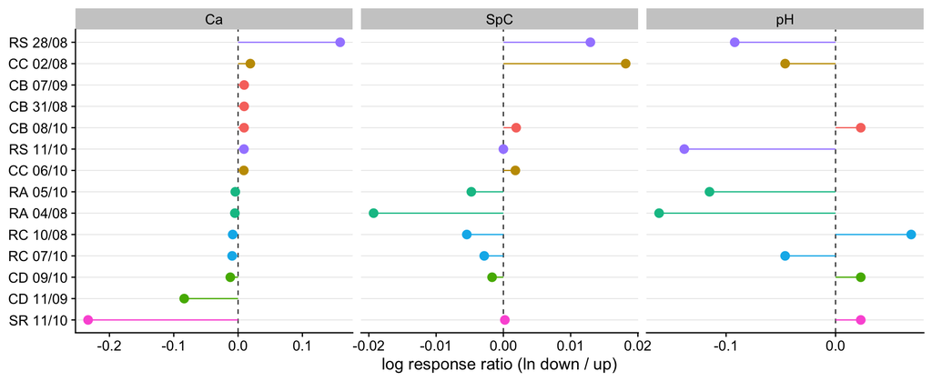

```r
ord <- geochem_check %>%
  mutate(event = paste(stream, format(date, "%d/%m"))) %>%
  arrange(lrr_ca) %>%
  pull(event)

geochem_check %>%
  mutate(event = factor(paste(stream, format(date, "%d/%m")), levels = ord)) %>%
  select(event, stream, lrr_ca, lrr_spc, lrr_h) %>%
  pivot_longer(starts_with("lrr_"), names_to = "series", values_to = "lrr") %>%
  filter(!is.na(lrr)) %>%
  mutate(series = factor(series,
    levels = c("lrr_ca", "lrr_spc", "lrr_h"),
    labels = c("Ca", "SpC", "pH"))) %>%
  ggplot(aes(lrr, event, colour = stream)) +
  geom_vline(xintercept = 0, linetype = "dashed", linewidth = 0.4) +
  geom_segment(aes(x = 0, xend = lrr, yend = event), linewidth = 0.5) +
  geom_point(size = 3) +
  facet_wrap(~ series, nrow = 1, scales = "free_x") +
  labs(x = "log response ratio (ln down / up)", y = NULL) +
  cowplot::theme_cowplot(font_size = 14) +
  theme(legend.position = "none",
        panel.grid.major.y = element_line(colour = "grey90", linewidth = 0.3))
```

> Calcium was determined by EDTA titration at a commercial laboratory and reported to 0.1 mg L⁻¹. Several events differ by exactly 0.4 mg L⁻¹, which is close to the reporting precision, so those changes are recorded but carry little weight. The uncertainty is quantified in Section 9.6.

## 9.5 Application

```r
# SIGMA_P: House (1990) reports several sigma estimates, and they cluster by
# solution type rather than scattering randomly -- field/river waters run
# 0.055-0.095 umol/m2 (River Frome, River Windrush, Waterston chalk
# aquifer), while idealised synthetic Ca(HCO3)2 solutions run 0.13-0.22
# umol/m2. This is a karst STREAM, not a synthetic solution, so the field
# cluster is the physically appropriate class. 5.5e-8 mol/m2 is the River
# Frome value (House et al. 1986a; the "river water" case House 1990
# itself highlights) -- the same value and reasoning Cohen et al. (2013,
# Ecol. Monogr. 83:2) used for the Ichetucknee River, a spring-fed
# karst/calcite stream directly analogous to this system, explicitly
# preferring the field value because natural water carries competing
# solutes (Mg, Fe, DOM) that reduce the effective sorption area, and
# because their own sensitivity check found the lab-range value inflates
# the correction ~47x and yields implausible C:P ratios. See Section 9.8
# for the corresponding sensitivity range in this pipeline.
SIGMA_P   <- 5.5e-8        # mol/m2 -- River Frome (House 1990 / Cohen et al. 2013)
D_CALCITE <- 2.01e-19      # m2/molecule, molecular surface area of calcite
N_AVOG    <- 6.02214076e23 # molecules/mol
R_GAS     <- 8.314         # J/mol/K
A1 <- 0.6915  ; E1 <- 18.2e3   # J/mol
A2 <- 4.361e-9; E2 <- 42.6e3   # J/mol

M_P  <- 30.973762   # g/mol
M_CA <- 40.078      # g/mol

h_langmuir2 <- function(a_PO4, a_HPO4, K1, K2) {
  num <- K1 * a_PO4 + K2 * a_HPO4
  num / (1 + num)
}
```

```r
act_path <- here("data_derived", "phreeqc_activities.csv")

if (!file.exists(act_path)) {
  warning("phreeqc_activities.csv nao encontrado: rode R/phreeqc_speciation.R. ",
          "As colunas de coprecipitacao ficarao NA.")
  coprec <- tibble(stream = character(), date = as.Date(character()),
                   sample_btc = numeric())
} else {
  # date is written as a bare integer (20231008) by the speciation script, so
  # it must be parsed with ymd(); as.Date() on a number silently yields a date
  # in year 57345 and every join returns NA.
  coprec <- read_csv(act_path, show_col_types = FALSE) %>%
    mutate(date = ymd(as.character(date))) %>%
    left_join(
      p_raw %>% select(stream, date, sample_btc, temp_c, ca_mgL_up, ca_mgL_down),
      by = c("stream", "date", "sample_btc")
    ) %>%
    mutate(
      T_K = temp_c + 273.15,
      k1_langmuir = A1 * exp(E1 / (R_GAS * T_K)),
      k2_langmuir = A2 * exp(E2 / (R_GAS * T_K)),
      # House's K1/K2 (Eq. 7-8) and the Langmuir isotherm (Eq. 9, House
      # 1990) are defined for [PO4^3-]/[HPO4^2-] in umol/dm^3 -- House
      # states this explicitly under Eq. 8 ("the concentrations of the
      # phosphate and hydrogenphosphate ions are expressed in units of
      # umol dm^-3"). PHREEQC's -activities output is on a mol/L numeric
      # scale, six orders of magnitude smaller; passing it to
      # h_langmuir2() unconverted collapses h_adsorbed toward ~0
      # regardless of how saturated the solution actually is -- this is
      # the second, larger reason the coprecipitation correction still
      # looked negligible after the SIGMA_P and major-ion mg/L fixes.
      h_adsorbed  = h_langmuir2(a_PO4 * 1e6, a_HPO4 * 1e6, k1_langmuir, k2_langmuir),

      # synoptic pair on arrival; positive = calcium lost across the reach
      delta_ca_mgL  = ca_mgL_up - ca_mgL_down,
      delta_ca_molL = delta_ca_mgL / (1000 * M_CA),

      p_coprec_molL = delta_ca_molL * (SIGMA_P * N_AVOG * D_CALCITE) * h_adsorbed,
      p_coprec_ugL  = p_coprec_molL * M_P * 1e6,

      flag_delta_ca_neg = delta_ca_mgL < 0
    ) %>%
    select(stream, date, sample_btc, a_PO4, a_HPO4, h_adsorbed,
           k1_langmuir, k2_langmuir, delta_ca_mgL, p_coprec_ugL,
           flag_delta_ca_neg)
}

# guard: the join must match. If this returns 0 rows the date types disagree.
cat("eventos com atividades pareadas:",
    nrow(distinct(coprec, stream, date)), "\n")
```

```
## eventos com atividades pareadas: 9
```

```r
# Adding p_coprec to the background-corrected concentration reconstructs the
# SRP that would have been present without abiotic removal:
#   (measured + coprecipitated) - background
# Background subtraction and this addition commute, so order is immaterial.
btc_nutrients <- btc_nutrients %>%
  select(-any_of(c("a_PO4", "a_HPO4", "h_adsorbed", "k1_langmuir",
                   "k2_langmuir", "delta_ca_mgL", "p_coprec_ugL",
                   "flag_delta_ca_neg", "conc_corr_coprec_ugL"))) %>%
  left_join(coprec, by = c("stream", "date", "sample_btc")) %>%
  mutate(
    across(c(a_PO4, a_HPO4, h_adsorbed, k1_langmuir, k2_langmuir,
             delta_ca_mgL, p_coprec_ugL),
           ~ if_else(solute == "SRP", .x, NA_real_)),
    flag_delta_ca_neg = if_else(solute == "SRP", flag_delta_ca_neg, NA),
    conc_corr_coprec_ugL = if_else(solute == "SRP",
                                   conc_corr_ugL + p_coprec_ugL,
                                   NA_real_)
  )

btc_nutrients %>%
  filter(solute == "SRP") %>%
  group_by(event_id) %>%
  summarise(
    n = n(),
    delta_ca_mgL = first(delta_ca_mgL),
    h_median     = median(h_adsorbed, na.rm = TRUE),
    coprec_median_ugL = median(p_coprec_ugL, na.rm = TRUE),
    frac_of_srp  = median(p_coprec_ugL / conc_corr_ugL, na.rm = TRUE),
    delta_ca_neg = first(flag_delta_ca_neg),
    .groups = "drop"
  ) %>%
  arrange(desc(delta_ca_mgL)) %>%
  print(n = Inf)
```

```
## # A tibble: 9 × 7
##   event_id                 n delta_ca_mgL h_median coprec_median_ugL frac_of_srp
##   <chr>                <int>        <dbl>    <dbl>             <dbl>       <dbl>
## 1 SR_20231011_single      27       10.4     0.0305            1.63       0.222
## 2 CD_20231009_single      29        0.900   0.0451            0.209      0.0159
## 3 RA_20230906_P           22        0.400   0.0198            0.0407     0.00758
## 4 CB_20231008_single      29        0.400   0.0253            0.0521     0.00306
## 5 CC_20231006_single      19        0.400   0.0361            0.0743     0.00398
## 6 RC_20231007_single      23        0.400   0.0689            0.142      0.00597
## 7 RS_20231011_single      21        0.400   0.0276            0.0567     0.00312
## 8 RA_20231005_downstr…    28        0.300   0.0167            0.0257     0.00827
## 9 CB_20230907_single      13       -0.400   0.0385           -0.0792    -0.00320
## # ℹ 1 more variable: delta_ca_neg <lgl>
```

> **QAQC note.** `frac_of_srp` is the size of the correction relative to the signal being corrected, and it decides how much any of this matters. Where it is small, the treatment of ΔCa < 0 cannot change a conclusion; where it approaches unity, the corrected series is largely model output rather than measurement, and the inverse fit should be reported for both series.

> Where `delta_ca_neg` is TRUE the reach gained calcium: calcite dissolved rather than precipitated. The House model returns a negative $n_{P,\mathrm{cop}}$ there, so the correction subtracts phosphorus, which is outside the direction the model was parameterised for. No precedent for this case exists in the BTC literature, so these events are flagged and carried forward, and robustness of the main conclusions is demonstrated across alternative treatments of them rather than one treatment being asserted as correct.

## 9.6 Calcium change: measurement uncertainty

`ca_mass_trans_mgL` (§9.4) is a difference of two independent EDTA titrations, upstream and downstream. Whether an observed difference reflects real transport or just analytical noise depends on how large it is relative to that noise, which this section quantifies rather than asserts.

Each of the two titrations (upstream, downstream) is treated as an independent measurement with relative standard deviation `CA_RSD` of its own concentration. For two independent errors of comparable relative size, the standard deviation of their difference is

$$\sigma_{\Delta\mathrm{Ca}} =
\sqrt{2}\;\mathrm{CA\_RSD}\;\overline{\mathrm{Ca}}$$

where $\overline{\mathrm{Ca}}$ is the mean of the upstream and downstream concentrations (used as the reference level since the true concentration is unknown) and the $\sqrt{2}$ comes from adding two equal-variance, independent errors in quadrature. The observed transfer is then expressed in units of its own uncertainty, $z = \Delta\mathrm{Ca}_{\mathrm{mass\ trans}} / \sigma_{\Delta\mathrm{Ca}}$; `flag_ca_resolved` marks events where $|z| > 1$, i.e. where the observed change exceeds one analytical standard deviation. No event is excluded by this — every row keeps its value and its flag, and the areal rate of §9.7 is reported for both resolved and unresolved events alike.

```r
CA_RSD <- 0.092   # Standard Methods 3500-Ca, EDTA titrimetric; interlaboratory
                  # RSD. NOT the method's 1.9% relative error, which is a bias
                  # against a reference, not a standard deviation.

geochem_check <- geochem_check %>%
  mutate(
    ca_mean_mgL      = (ca_mgL_up + ca_mgL_down) / 2,
    ca_delta_sd      = sqrt(2) * CA_RSD * ca_mean_mgL,
    ca_delta_z       = ca_mass_trans_mgL / ca_delta_sd,
    flag_ca_resolved = abs(ca_delta_z) > 1
  )

geochem_check %>%
  select(stream, date, ca_mass_trans_mgL, ca_mean_mgL, ca_delta_sd,
         ca_delta_z, flag_ca_resolved) %>%
  arrange(abs(ca_delta_z)) %>%
  print(n = Inf)
```

```
## # A tibble: 14 × 7
##    stream date       ca_mass_trans_mgL ca_mean_mgL ca_delta_sd ca_delta_z
##    <chr>  <date>                 <dbl>       <dbl>       <dbl>      <dbl>
##  1 RA     2023-10-05            -0.300        69.4        9.04    -0.0332
##  2 RA     2023-08-04            -0.400        80.3       10.4     -0.0383
##  3 RC     2023-08-10            -0.400        47.9        6.23    -0.0642
##  4 CC     2023-10-06             0.400        44.8        5.83     0.0686
##  5 RS     2023-10-11             0.400        43.7        5.69     0.0704
##  6 RC     2023-10-07            -0.400        43.3        5.63    -0.0710
##  7 CB     2023-10-08             0.400        42.9        5.58     0.0717
##  8 CB     2023-08-31             0.400        42.2        5.49     0.0729
##  9 CB     2023-09-07             0.400        42.2        5.49     0.0729
## 10 CD     2023-10-09            -0.800        66.2        8.61    -0.0929
## 11 CC     2023-08-02             0.900        47.2        6.15     0.146
## 12 CD     2023-09-11            -5.60         66.9        8.70    -0.643
## 13 RS     2023-08-28             6.4          40.4        5.26     1.22
## 14 SR     2023-10-11           -10.4          44.8        5.83    -1.78
## # ℹ 1 more variable: flag_ca_resolved <lgl>
```

## 9.7 Areal calcium precipitation rate

A concentration difference alone is not comparable between reaches: 1 mg/L lost over a 52 m reach (CD) reflects a far more intense process than the same 1 mg/L over 408 m (RS). Normalising by reach length and residence time, and by wetted area, gives a rate that **is** comparable:

$$r_A =
\frac{\Delta[\mathrm{Ca}]}{L/v}\cdot 10^3 \cdot z
\qquad\text{(route 1: BTC hydraulics)}$$

$$r_A =
\frac{Q\,\Delta[\mathrm{Ca}]}{L\,w}
\qquad\text{(route 2: campaign discharge)}$$

Both reduce to the same quantity under continuity ($Q = v\,w\,z$) and are computed side by side as a mutual check: the $10^3$ in route 1 converts $\Delta[\mathrm{Ca}]$ from mg/L to mg/m³ so both routes come out in the same units, mg m⁻² s⁻¹. $\Delta[\mathrm{Ca}]$ is `ca_mass_trans_mgL` negated (§9.4 convention: positive = calcium lost, matching the sign `r_A` is meant to carry), $L$ is the calcium reach length of `calcium_reach_change.csv` (not necessarily the BTC slug reach — the two differ for several events, e.g. CB 2023-08-31 at 252 m against 162 m for the BTC reach), and $w$ is the fixed per-stream width of `data/field/streams_width.csv`.

Because $r_A$ is linear in $Q$, the spread across candidate discharges at a site (`Q_min_ponto`, `Q_max_ponto` from `qaqc_discharge_records.R`, and `Q_alt` for RA 2023-08-04’s alternative mass reading) **is** the spread of the rate, so it is reported alongside the point estimate rather than folded into a single number.

```r
# Route 1 needs one unambiguous velocity and depth per stream-date, which
# only exists for single (non-split) BTC events.
btc_hydraulics_single <- events %>%
  filter(is.na(station), is.na(slug_label)) %>%
  transmute(stream, date, v_btc_ms = water_velocity_ms, z_btc_m = stream_depth_m)

streams_width <- read_csv(here("data", "field", "streams_width.csv"),
                          show_col_types = FALSE)

discharge_for_calcium <- read_csv(here("data_derived", "discharge_for_calcium.csv"),
                                  show_col_types = FALSE) %>%
  transmute(stream = Site, date = date_ca, Q_calcium_Ls = Q_Ls,
            Q_min_ponto, Q_max_ponto, Q_alt, flag_sem_vazao)

areal_ca <- geochem_check %>%
  transmute(stream, date, reach_length_m, ca_mass_trans_mgL,
            ca_loss_mgL = -ca_mass_trans_mgL) %>%   # House convention: positive = lost
  left_join(btc_hydraulics_single, by = c("stream", "date")) %>%
  left_join(streams_width,         by = "stream") %>%
  left_join(discharge_for_calcium, by = c("stream", "date")) %>%
  mutate(
    flag_no_width = is.na(mean_width_m),
    flag_no_btc_v = is.na(v_btc_ms),
    flag_no_q     = is.na(Q_calcium_Ls) | coalesce(flag_sem_vazao, TRUE),

    r_areal_btc_mgm2s      = (ca_loss_mgL / (reach_length_m / v_btc_ms)) * 1000 * z_btc_m,
    r_areal_campaign_mgm2s = (Q_calcium_Ls * ca_loss_mgL) / (reach_length_m * mean_width_m),
    r_areal_Qmin_mgm2s     = (Q_min_ponto  * ca_loss_mgL) / (reach_length_m * mean_width_m),
    r_areal_Qmax_mgm2s     = (Q_max_ponto  * ca_loss_mgL) / (reach_length_m * mean_width_m),
    r_areal_Qalt_mgm2s     = (Q_alt        * ca_loss_mgL) / (reach_length_m * mean_width_m),

    # per-day convenience unit alongside the SI (mg m-2 s-1) value
    r_areal_campaign_mgm2d = r_areal_campaign_mgm2s * 86400,

    route_disagreement_pct = 100 * (r_areal_btc_mgm2s - r_areal_campaign_mgm2s) /
                              r_areal_campaign_mgm2s
  ) %>%
  arrange(stream, date)

areal_ca %>%
  select(stream, date, ca_loss_mgL, reach_length_m, mean_width_m,
         r_areal_btc_mgm2s, r_areal_campaign_mgm2s, r_areal_campaign_mgm2d,
         route_disagreement_pct, flag_no_width, flag_no_btc_v, flag_no_q) %>%
  print(n = Inf)
```

```
## # A tibble: 14 × 12
##    stream date       ca_loss_mgL reach_length_m mean_width_m r_areal_btc_mgm2s
##    <chr>  <date>           <dbl>          <dbl>        <dbl>             <dbl>
##  1 CB     2023-08-31      -0.400            252         7.75           NA
##  2 CB     2023-09-07      -0.400            252         7.75           -0.0785
##  3 CB     2023-10-08      -0.400            162         7.75           -0.101
##  4 CC     2023-08-02      -0.900            126         3.11           NA
##  5 CC     2023-10-06      -0.400            184         3.11           -0.135
##  6 CD     2023-09-11       5.60              52         5.49           NA
##  7 CD     2023-10-09       0.800             52         5.49            0.0830
##  8 RA     2023-08-04       0.400            206         9.47           NA
##  9 RA     2023-10-05       0.300            137         9.47           NA
## 10 RC     2023-08-10       0.400            340         7.86           NA
## 11 RC     2023-10-07       0.400            150         7.86            0.170
## 12 RS     2023-08-28      -6.4              408         7.92           NA
## 13 RS     2023-10-11      -0.400            408         7.92           -0.155
## 14 SR     2023-10-11      10.4               72         2               0.427
## # ℹ 6 more variables: r_areal_campaign_mgm2s <dbl>,
## #   r_areal_campaign_mgm2d <dbl>, route_disagreement_pct <dbl>,
## #   flag_no_width <lgl>, flag_no_btc_v <lgl>, flag_no_q <lgl>
```

```r
cat("\n--- espalhamento da vazao (rota da campanha) ---\n")
```

```
##
## --- espalhamento da vazao (rota da campanha) ---
```